# Blood Donation Prediction

Predicting blood donation of individuals in March 2007

Nov 2017

## 1) Introduction

This data is obtained from a mobile blood donation vehicle in Taiwan. The Blood Transfusion Service Center drives to different universities and collects blood as part of a blood drive. This data is stored at UCI Machine Learning repository. https://archive.ics.uci.edu/ml/datasets/Blood+Transfusion+Service+Center

Predictors provided are: 1. months since last donation

2. total number of donation
3. Total Volume Donated (c.c.)
4. Months since First Donation

We want to make predictions based on these characteristics to see if the person dontaes blood on March 2007.

### 1a) Data Cleansing

We start with loading and cleaning the data for training and testing

```r
datamodel=read.csv("DonationTraining.csv")
summary(datamodel)
```

```
##        X         Months.since.Last.Donation Number.of.Donations
##  Min.   :  0.0   Min.   : 0.000             Min.   : 1.000
##  1st Qu.:183.8   1st Qu.: 2.000             1st Qu.: 2.000
##  Median :375.5   Median : 7.000             Median : 4.000
##  Mean   :374.0   Mean   : 9.439             Mean   : 5.427
##  3rd Qu.:562.5   3rd Qu.:14.000             3rd Qu.: 7.000
##  Max.   :747.0   Max.   :74.000             Max.   :50.000
##  Total.Volume.Donated..c.c.. Months.since.First.Donation
##  Min.   :  250               Min.   : 2.00
##  1st Qu.:  500               1st Qu.:16.00
##  Median : 1000               Median :28.00
##  Mean   : 1357               Mean   :34.05
##  3rd Qu.: 1750               3rd Qu.:49.25
##  Max.   :12500               Max.   :98.00
##  Made.Donation.in.March.2007
##  Min.   :0.0000
##  1st Qu.:0.0000
##  Median :0.0000
##  Mean   :0.2396
##  3rd Qu.:0.0000
##  Max.   :1.0000
```

```r
sum(is.na(datamodel[,]))
```

```
## [1] 0
```

There is no missing values in the data;

Our variable of interest “Made.Donation.In.March.2007” are binary values; 1 means the person donated blood in March 2007, while 0 means he/she did not

```r
datamodel$Made.Donation.in.March.2007=as.factor(datamodel$Made.Donation.in.March.2007)
```

### 1b) Visualisation of data

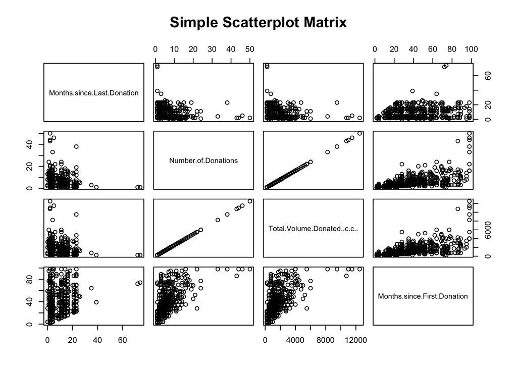

```r
library(lattice)
pairs(~Months.since.Last.Donation+Number.of.Donations+Total.Volume.Donated..c.c..+Months.since.First.Donation,data=datamodel,
      main="Simple Scatterplot Matrix")
```

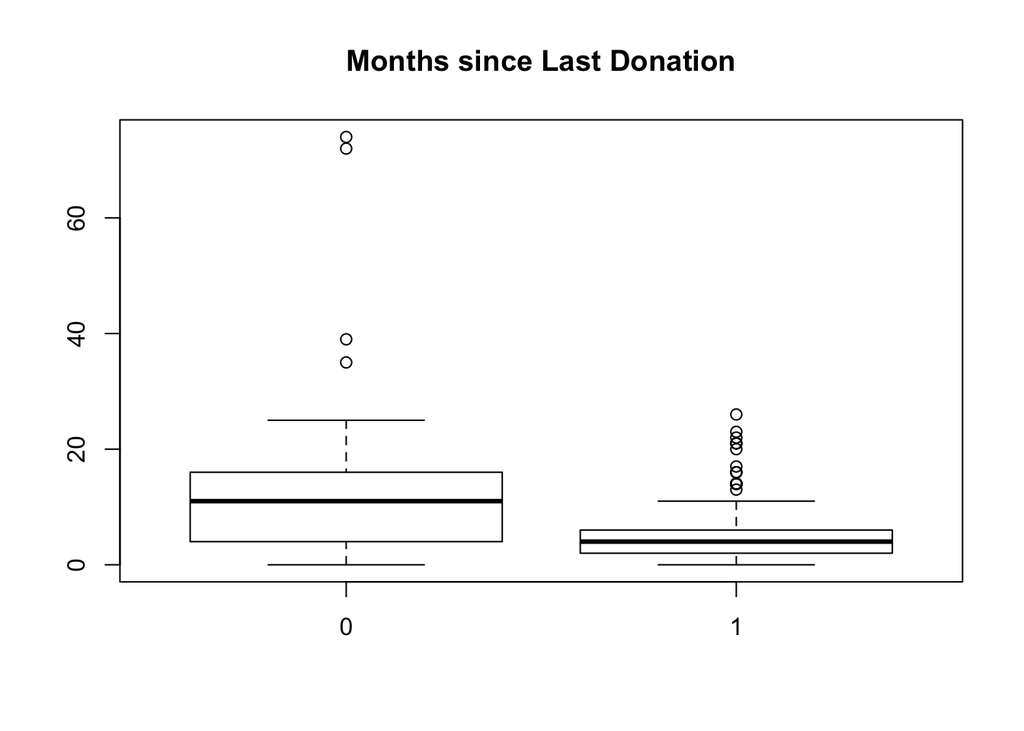

```r
plot(datamodel$Made.Donation.in.March.2007,datamodel$Months.since.Last.Donation,main="Months since Last Donation")
```

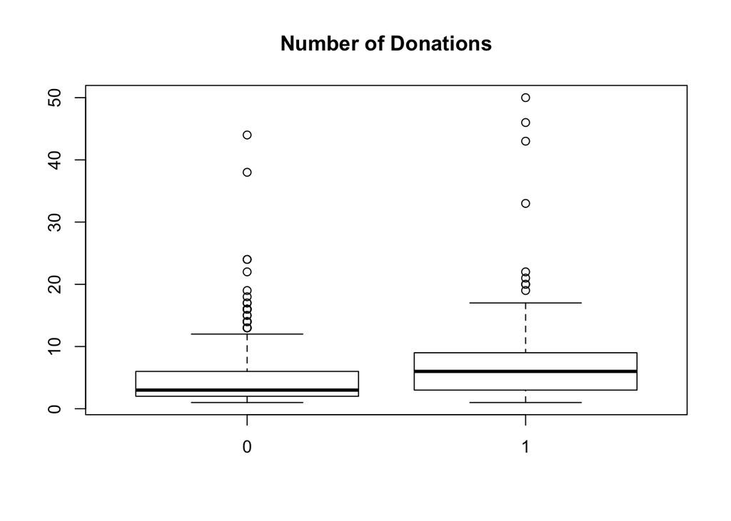

```r
plot(datamodel$Made.Donation.in.March.2007,datamodel$Number.of.Donations,main="Number of Donations")
```

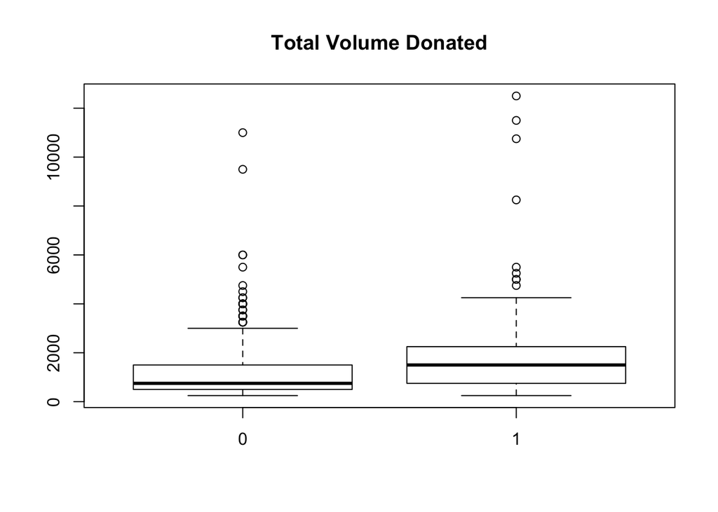

```r
plot(datamodel$Made.Donation.in.March.2007,datamodel$Total.Volume.Donated..c.c..,main="Total Volume Donated")
```

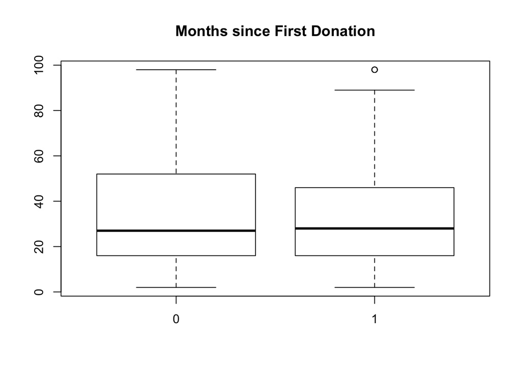

```r
plot(datamodel$Made.Donation.in.March.2007,datamodel$Months.since.First.Donation,main="Months since First Donation")
```

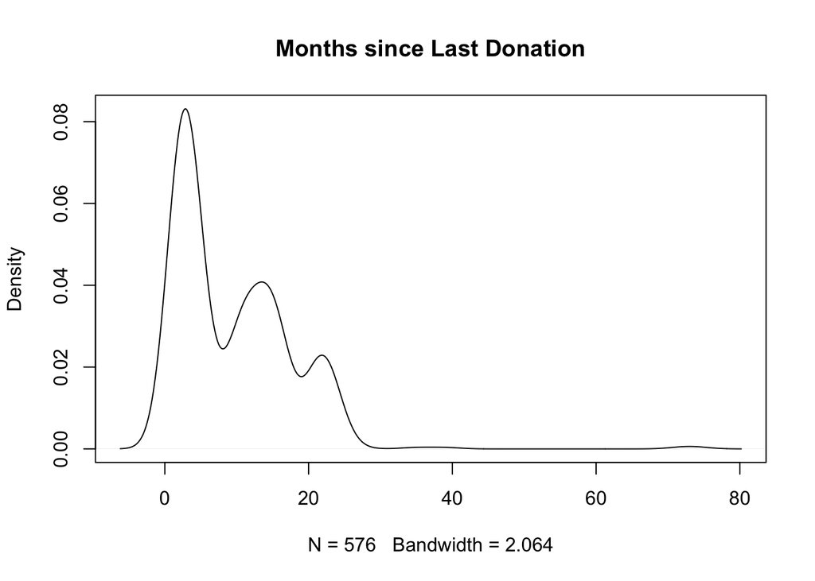

```r
plot(density(datamodel$Months.since.Last.Donation),main="Months since Last Donation")
```

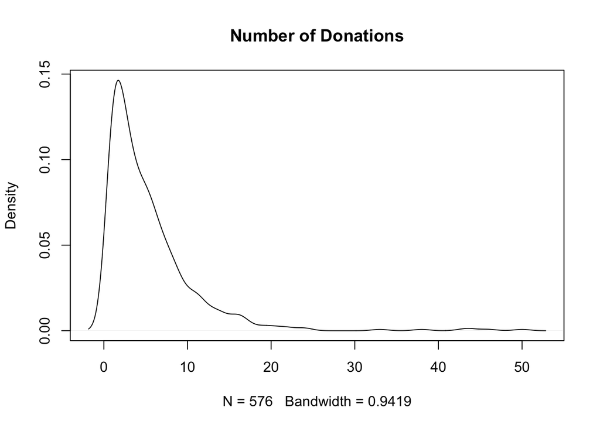

```r
plot(density(datamodel$Number.of.Donations),main="Number of Donations")
```

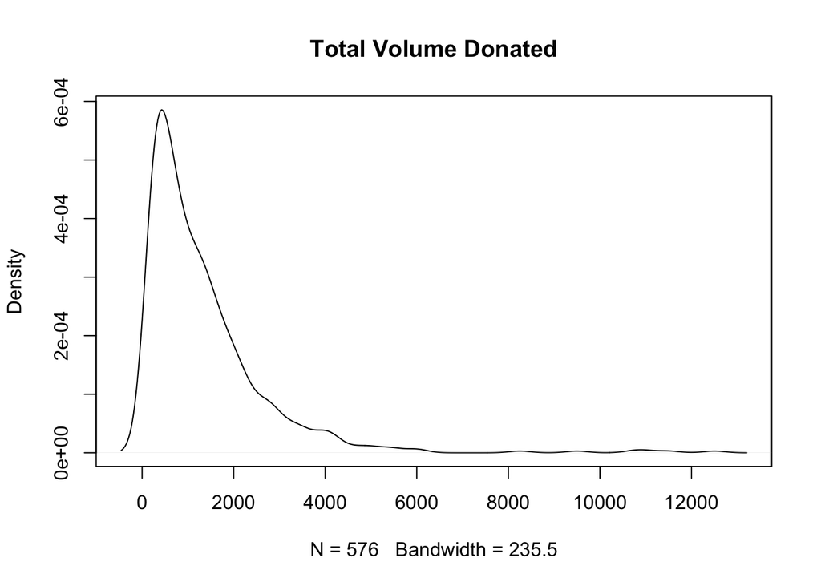

```r
plot(density(datamodel$Total.Volume.Donated..c.c..),main="Total Volume Donated")
```

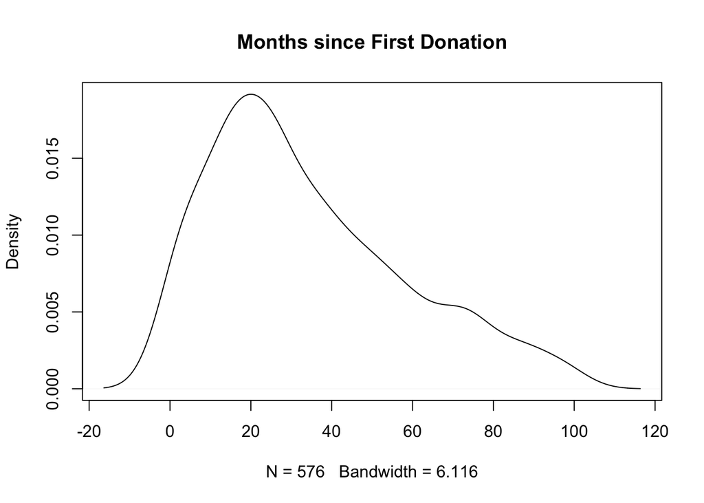

```r
plot(density(datamodel$Months.since.First.Donation),main="Months since First Donation")
```

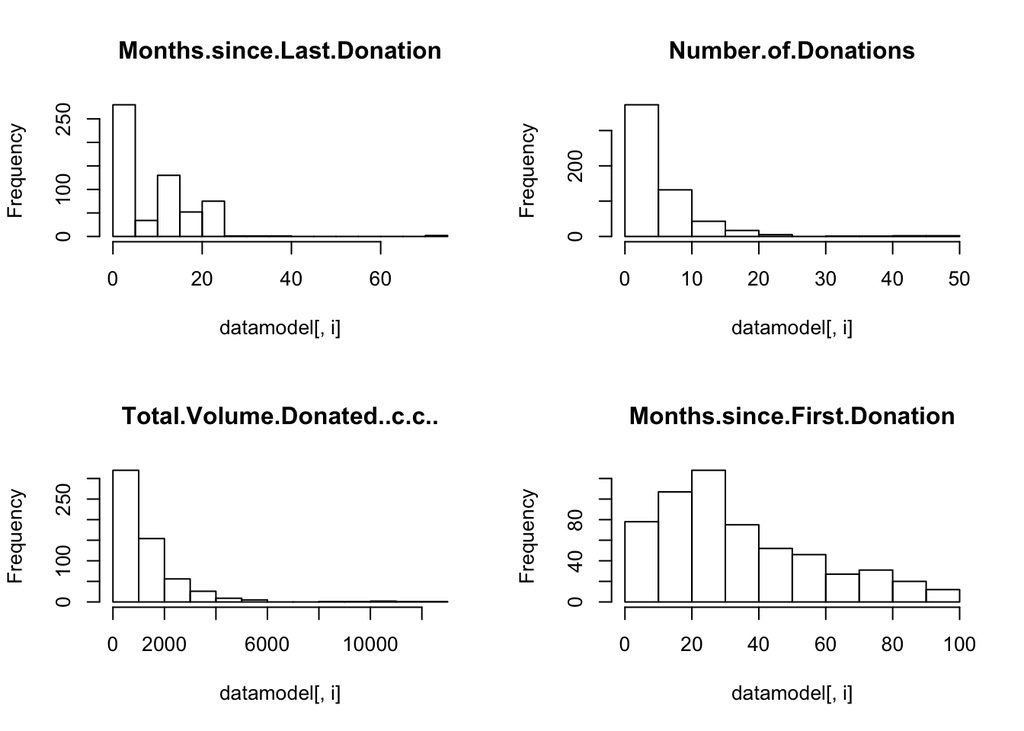

```r
par(mfrow=c(2,2))
for(i in 2:5) {
  hist(datamodel[,i], main=names(datamodel)[i])
}
```

### 1b) Feature Engineering

There is a multicollinearity issue in the model because Number.Of.Donations and Total.Volume.Donated..c.c.. are perfectly correlated (the correlation is 1). So we consider only one of the two variables - Number.Of.Donations

```r
datamodel = datamodel[, -4]
```

### 1c) Splitting of Data into training and validation set

We split the data into training and validation set to enable testing of the various models

```r
a=229629
N=nrow(datamodel)
set.seed(a)
Perct=0.7
train.index <- sample(1:N, round(N*Perct))
test.index <- - train.index

datatrain=datamodel[train.index,]
datavalid=datamodel[test.index,]

xtrain=model.matrix(Made.Donation.in.March.2007 ~ ., datatrain)[,-c(1,2)]
ytrain=datatrain[, "Made.Donation.in.March.2007"]
xvalid=model.matrix(Made.Donation.in.March.2007 ~ ., datavalid)[,-c(1,2)]
yvalid=datavalid[, "Made.Donation.in.March.2007"]
```

## 2) Building Models

We build a series of models and predict the probabilities of a person returning to donate blood on March 2007

### 2a) Logistic Model…

```r
## Logistic regression model
glm <- glm(Made.Donation.in.March.2007 ~ ., data=datatrain, family=binomial())
summary(glm)
```

```
##
## Call:
## glm(formula = Made.Donation.in.March.2007 ~ ., family = binomial(),
##     data = datatrain)
##
## Deviance Residuals:
##     Min       1Q   Median       3Q      Max
## -2.3767  -0.8111  -0.5233  -0.2432   2.6048
##
## Coefficients:
##                               Estimate Std. Error z value Pr(>|z|)
## (Intercept)                 -0.5555155  0.3160777  -1.758 0.078828 .
## X                            0.0001671  0.0005857   0.285 0.775411
## Months.since.Last.Donation  -0.0927691  0.0229415  -4.044 5.26e-05 ***
## Number.of.Donations          0.1280761  0.0331831   3.860 0.000114 ***
## Months.since.First.Donation -0.0220005  0.0079957  -2.752 0.005932 **
## ---
## Signif. codes:  0 '***' 0.001 '**' 0.01 '*' 0.05 '.' 0.1 ' ' 1
##
## (Dispersion parameter for binomial family taken to be 1)
##
##     Null deviance: 444.81  on 402  degrees of freedom
## Residual deviance: 392.39  on 398  degrees of freedom
## AIC: 402.39
##
## Number of Fisher Scoring iterations: 5
```

```r
## model selectin by AIC
library("MASS")
glm.best <- stepAIC(glm, direction="both")
```

```
## Start:  AIC=402.39
## Made.Donation.in.March.2007 ~ X + Months.since.Last.Donation +
##     Number.of.Donations + Months.since.First.Donation
##
##                               Df Deviance    AIC
## - X                            1   392.47 400.47
## <none>                             392.39 402.39
## - Months.since.First.Donation  1   400.87 408.87
## - Number.of.Donations          1   410.12 418.12
## - Months.since.Last.Donation   1   411.24 419.24
##
## Step:  AIC=400.47
## Made.Donation.in.March.2007 ~ Months.since.Last.Donation + Number.of.Donations +
##     Months.since.First.Donation
##
##                               Df Deviance    AIC
## <none>                             392.47 400.47
## + X                            1   392.39 402.39
## - Months.since.First.Donation  1   400.91 406.91
## - Number.of.Donations          1   410.29 416.29
## - Months.since.Last.Donation   1   411.41 417.41
```

```r
summary(glm.best)
```

```
##
## Call:
## glm(formula = Made.Donation.in.March.2007 ~ Months.since.Last.Donation +
##     Number.of.Donations + Months.since.First.Donation, family = binomial(),
##     data = datatrain)
##
## Deviance Residuals:
##     Min       1Q   Median       3Q      Max
## -2.3995  -0.8075  -0.5246  -0.2428   2.5980
##
## Coefficients:
##                              Estimate Std. Error z value Pr(>|z|)
## (Intercept)                 -0.493900   0.230182  -2.146 0.031898 *
## Months.since.Last.Donation  -0.092839   0.022915  -4.051 5.09e-05 ***
## Number.of.Donations          0.128391   0.033181   3.869 0.000109 ***
## Months.since.First.Donation -0.021925   0.007983  -2.746 0.006026 **
## ---
## Signif. codes:  0 '***' 0.001 '**' 0.01 '*' 0.05 '.' 0.1 ' ' 1
##
## (Dispersion parameter for binomial family taken to be 1)
##
##     Null deviance: 444.81  on 402  degrees of freedom
## Residual deviance: 392.47  on 399  degrees of freedom
## AIC: 400.47
##
## Number of Fisher Scoring iterations: 5
```

```r
## categorical prediction (use fixed cutoff = 0.5)
glm.prob <- predict(glm.best, newdata=datavalid, type="response")
glm.pred <- ifelse(glm.prob > 0.5,"P1","P0")

# confusion matrix
confusion.mat <- table(glm.pred, datavalid$Made.Donation.in.March.2007)
confusion.mat
```

```
##
## glm.pred   0   1
##       P0 130  37
##       P1   2   4
```

```r
misclassfication_rate_glm <- 1 - (confusion.mat[2, 2] + confusion.mat[1, 1]) / nrow(datavalid)
misclassfication_rate_glm
```

```
## [1] 0.2254335
```

### 2b) Ridge Regression models

```r
##Set the same seed as previous models

library(glmnet)
set.seed(a)
ridgecv=cv.glmnet(xtrain,ytrain,family = "binomial", alpha = 0,type.measure = "class",nfolds=5)
ridgelam=ridgecv$lambda.min
##optimal lambda for ridge
ridgelam
```

```
## [1] 0.05681748
```

```r
coeffridge=predict(ridgecv, type="coefficient", s=ridgelam)
coeffridge
```

```
## 4 x 1 sparse Matrix of class "dgCMatrix"
##                                       1
## (Intercept)                 -0.68504565
## Months.since.Last.Donation  -0.06791204
## Number.of.Donations          0.07039976
## Months.since.First.Donation -0.01003391
```

```r
## categorical prediction (use fixed cutoff = 0.5)
ridge.prob <- predict(ridgecv, s=ridgelam, newx=xvalid,exact=TRUE,type="response")
#hist(Default$glm4.prob)
ridge.pred <- ifelse(ridge.prob > 0.5,"P1","P0")

# confusion matrix
confusion.mat <- table(ridge.pred, datavalid$Made.Donation.in.March.2007)
confusion.mat
```

```
##
## ridge.pred   0   1
##         P0 132  39
##         P1   0   2
```

```r
misclassfication_rate_ridge <- 1 - (confusion.mat[2, 2] + confusion.mat[1, 1]) / nrow(datavalid)
misclassfication_rate_ridge
```

```
## [1] 0.2254335
```

### 2c) Lasso Model

```r
##Set the same see as previous models
set.seed(a)
lassocv=cv.glmnet(xtrain,ytrain,family = "binomial", alpha = 1,type.measure = "class",nfolds=5)
lassolam=lassocv$lambda.min
##optimal lambda for ridge
lassolam
```

```
## [1] 0.01509122
```

```r
coefflasso=predict(lassocv, type="coefficient", s=lassolam)
coefflasso
```

```
## 4 x 1 sparse Matrix of class "dgCMatrix"
##                                        1
## (Intercept)                 -0.625251045
## Months.since.Last.Donation  -0.082493646
## Number.of.Donations          0.076858865
## Months.since.First.Donation -0.009984808
```

```r
## categorical prediction (use fixed cutoff = 0.5)
lasso.prob <- predict(lassocv, s=lassolam, newx=xvalid,exact=TRUE,type="response")
#hist(Default$glm4.prob)
lasso.pred <- ifelse(lasso.prob > 0.5,"P1","P0")

# confusion matrix
confusion.mat <- table(lasso.pred, datavalid$Made.Donation.in.March.2007)
confusion.mat
```

```
##
## lasso.pred   0   1
##         P0 132  39
##         P1   0   2
```

```r
misclassfication_rate_lasso <- 1 - (confusion.mat[2, 2] + confusion.mat[1, 1]) / nrow(datavalid)
misclassfication_rate_lasso
```

```
## [1] 0.2254335
```

### 2d) Elastic Model

```r
set.seed(a)
K=10
n=nrow(xtrain)
fold=sample(rep(seq(K),length=n))

alphas <- seq(0, 1, 0.01)
elscv.error = data.frame(alpha=alphas)
for (i in 1:length(alphas)){
  elscv = cv.glmnet(xtrain, ytrain, family="binomial", alpha=alphas[i], foldid=fold,type.measure = "class")
  elscv.error[i, "lambda.min"] = elscv$lambda.min
  elscv.error[i, "error.min"] = min(elscv$cvm)
}

##optimal alpha & lambda for elastic mod
elslam=elscv.error[which.min(elscv.error$error.min), "lambda.min"]
elsalpha=elscv.error[which.min(elscv.error$error.min), "alpha"]
elslam
```

```
## [1] 0.04298034
```

```r
elsalpha
```

```
## [1] 0
```

```r
set.seed(a)
##prediction of test data using mod with optimal alpha & lambda
elscv=cv.glmnet(xtrain, ytrain,family = "binomial", alpha = elsalpha,type.measure = "class",nfolds=5)
coeffels=predict(elscv, type="coefficient", s=elslam)
coeffels
```

```
## 4 x 1 sparse Matrix of class "dgCMatrix"
##                                       1
## (Intercept)                 -0.65085925
## Months.since.Last.Donation  -0.07260112
## Number.of.Donations          0.07775085
## Months.since.First.Donation -0.01146101
```

```r
## categorical prediction (use fixed cutoff = 0.5)
en.prob <- predict(elscv,s=elslam,newx=xvalid,type="response",exact=TRUE)
#hist(Default$glm4.prob)
en.pred <- ifelse(en.prob > 0.5,"P1","P0")

# confusion matrix
confusion.mat <- table(en.pred, datavalid$Made.Donation.in.March.2007)
confusion.mat
```

```
##
## en.pred   0   1
##      P0 132  39
##      P1   0   2
```

```r
misclassfication_rate_en <- 1 - (confusion.mat[2, 2] + confusion.mat[1, 1]) / nrow(datavalid)
misclassfication_rate_en
```

```
## [1] 0.2254335
```

## 2e) Tree

```r
library("tree")

##Growing a tree
tree1=tree(Made.Donation.in.March.2007~.,data=datatrain[,-1])
summary(tree1)
```

```
##
## Classification tree:
## tree(formula = Made.Donation.in.March.2007 ~ ., data = datatrain[,
##     -1])
## Number of terminal nodes:  6
## Residual mean deviance:  0.9177 = 364.3 / 397
## Misclassification error rate: 0.206 = 83 / 403
```

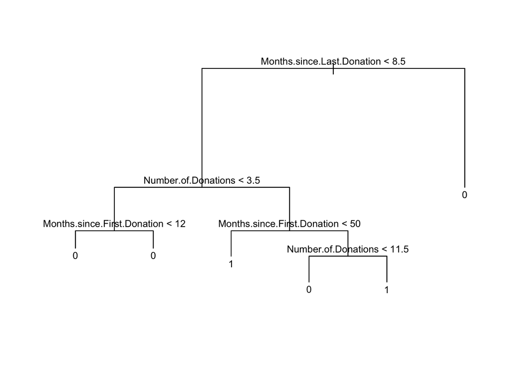

```r
plot(tree1)
text(tree1,cex=0.8)
```

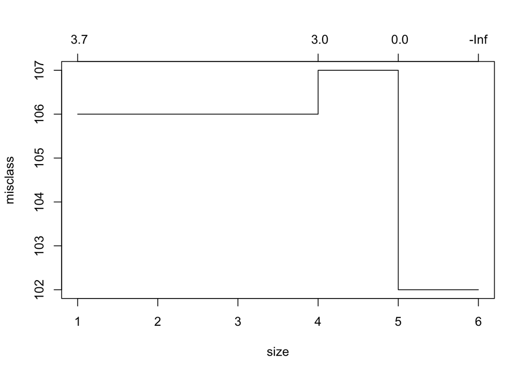

```r
##Pruning by CV
set.seed(a)
tree1.cv=cv.tree(tree1,method="misclass",K=10)
plot(tree1.cv)
```

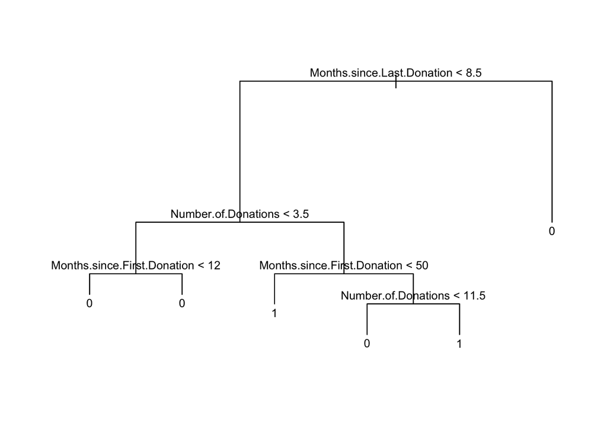

```r
##optimal size
optimal1=which.min(tree1.cv$dev)
optimal.size1=tree1.cv$size[optimal1]

##final pruned tree
tree1.pruned=prune.tree(tree1,best=optimal.size1)
plot(tree1.pruned)
text(tree1.pruned,cex=0.8)
```

```r
## categorical prediction (use fixed cutoff = 0.5)
tree.prob <- predict(tree1.pruned,newdata=datavalid,type="vector")
#hist(Default$glm4.prob)
tree.pred <- ifelse(tree.prob[,2] > 0.5,"P1","P0")

# confusion matrix
confusion.mat <- table(tree.pred, datavalid$Made.Donation.in.March.2007)
confusion.mat
```

```
##
## tree.pred   0   1
##        P0 108  17
##        P1  24  24
```

```r
misclassfication_rate_tree <- 1 - (confusion.mat[2, 2] + confusion.mat[1, 1]) / nrow(datavalid)
misclassfication_rate_tree
```

```
## [1] 0.2369942
```

## 2f) Random Forest

```r
library("randomForest")

##find optimal mtry
p=(ncol(datatrain)-2)
mserf=rep(0,p)
for (i in 1:p){
  set.seed(a)
  rf=randomForest(Made.Donation.in.March.2007~.,data=datatrain[,-1],ntree=1001,mtry=i)
  mserf[i]=rf$err.rate[1001]
}
optimal2=which.min(mserf)

##random forest  with optimal mtry
set.seed(a)
tree2=randomForest(Made.Donation.in.March.2007~.,data=datatrain[,-1],ntree=1001,mtry=optimal2)

importance(tree2)
```

```
##                             MeanDecreaseGini
## Months.since.Last.Donation          28.90464
## Number.of.Donations                 27.01592
## Months.since.First.Donation         33.84954
```

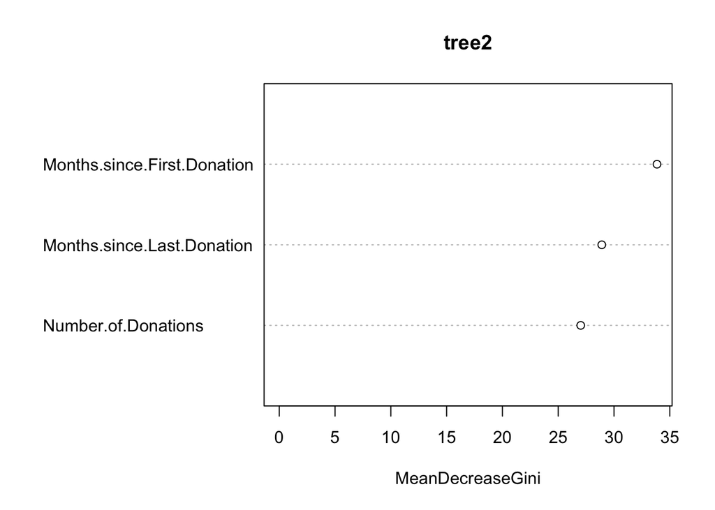

```r
varImpPlot(tree2)
```

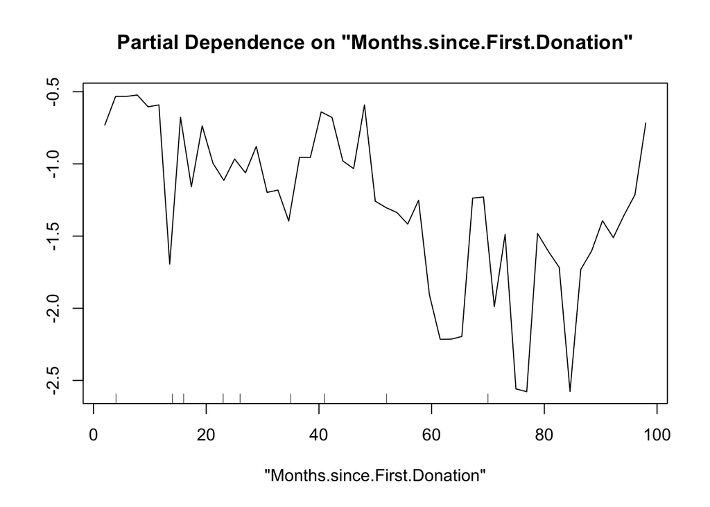

```r
partialPlot(tree2, datatrain,x.var="Months.since.First.Donation",which.class="1")
```

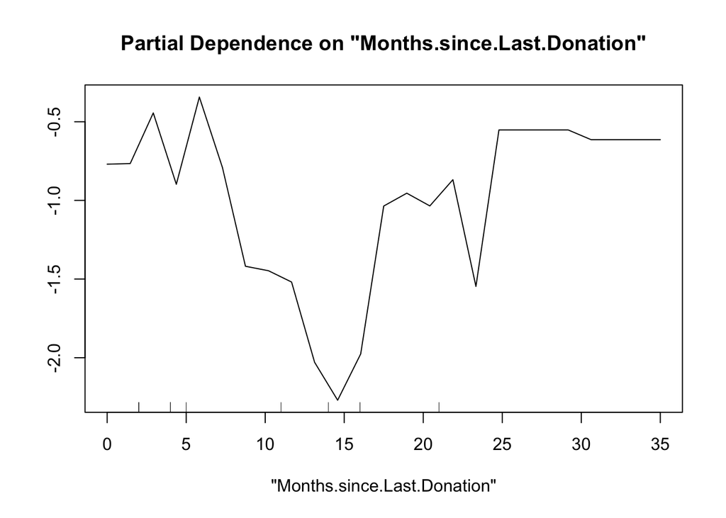

```r
partialPlot(tree2, datatrain,x.var="Months.since.Last.Donation",which.class="1")
```

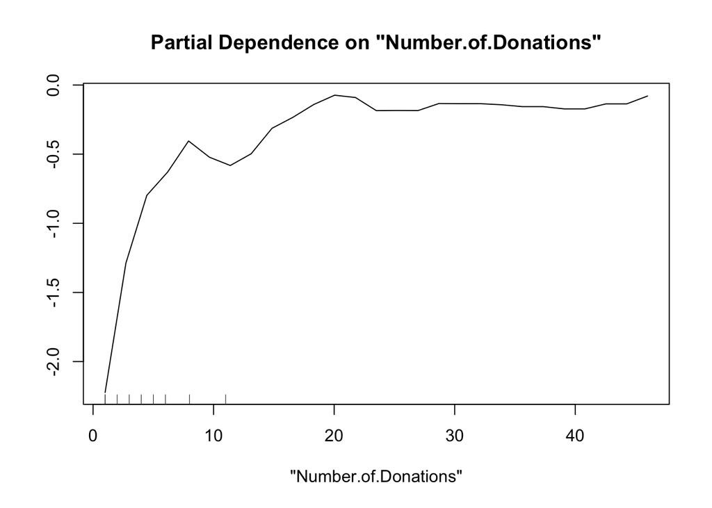

```r
partialPlot(tree2, datatrain,x.var="Number.of.Donations",which.class="1")
```

```r
## categorical prediction (use fixed cutoff = 0.5)
rf.prob <- predict(tree2,newdata=datavalid,type="prob")
rf.pred <- ifelse(rf.prob[,2] > 0.5,"P1","P0")

# confusion matrix
confusion.mat <- table(rf.pred, datavalid$Made.Donation.in.March.2007)
confusion.mat
```

```
##
## rf.pred   0   1
##      P0 118  24
##      P1  14  17
```

```r
misclassfication_rate_rf <- 1 - (confusion.mat[2, 2] + confusion.mat[1, 1]) / nrow(datavalid)
misclassfication_rate_rf
```

```
## [1] 0.2196532
```

### 2g) Gradient Boosting MAchine

````r
library("xgboost")
library("ggplot2")
ytrainnum=as.numeric(ytrain)-1
dtrain <- xgb.DMatrix(data=xtrain, label=ytrainnum)

objective <- "binary:logistic"
cv.fold <- 10
#```

# parameter ranges
max_depths <- c(1, 2, 3)  # candidates for d
etas <- c(0.01,0.0075, 0.005, 0.001)  # candidates for lambda
subsamples <- c(0.3,0.4,0.5,0.6, 0.75, 1)
colsamples <- c(0.6, 0.8,0.9,0.95,1)

# tune.out <- data.frame()
# for (max_depth in max_depths) {
#   for (eta in etas) {
#     for (subsample in subsamples) {
#       for (colsample in colsamples) {
#         # **calculate max n.trees**
#         n.max <- round(100 / (eta * sqrt(max_depth)))
#         set.seed(a)
#         xgb.cv.fit <- xgb.cv(data = dtrain, objective=objective, nfold=cv.fold, early_stopping_rounds=100, verbose=0,
#                              nrounds=n.max, max_depth=max_depth, eta=eta, subsample=subsample, colsample_bytree=colsample)
#         n.best <- xgb.cv.fit$best_ntreelimit
#         if (objective == "reg:linear") {
#           cv.err <- xgb.cv.fit$evaluation_log$test_rmse_mean[n.best]
#         } else if (objective == "binary:logistic") {
#           cv.err <- xgb.cv.fit$evaluation_log$test_error_mean[n.best]
#         }
#         out <- data.frame(max_depth=max_depth, eta=eta, subsample=subsample, colsample=colsample, n.max=n.max, nrounds=n.best, cv.err=cv.err)
#         tune.out <- rbind(tune.out, out)
#       }
#     }
#   }
# }
# opt <- which.min(tune.out$cv.err)
# max_depth.opt <- tune.out$max_depth[opt]
# eta.opt <- tune.out$eta[opt]
# subsample.opt <- tune.out$subsample[opt]
# colsample.opt <- tune.out$colsample[opt]
# nrounds.opt <- tune.out$nrounds[opt]

opt <- 305
max_depth.opt <- 3
eta.opt <- 0.005
subsample.opt <- 0.3
colsample.opt <- 1
nrounds.opt <- 204

# final model
set.seed(a)
xgbmod=xgboost(data=dtrain, objective="binary:logistic", nround=nrounds.opt, max.depth=max_depth.opt, eta=eta.opt, subsample=subsample.opt, colsample_bytree=colsample.opt)
# variable importance
importance_matrix <- xgb.importance(model = xgbmod, feature_names = colnames(xtrain))
importance_matrix
````

```
##                        Feature      Gain     Cover Frequency
## 1:  Months.since.Last.Donation 0.3818113 0.3776852 0.2771574
## 2:         Number.of.Donations 0.3450441 0.3478363 0.3390863
## 3: Months.since.First.Donation 0.2731445 0.2744785 0.3837563
```

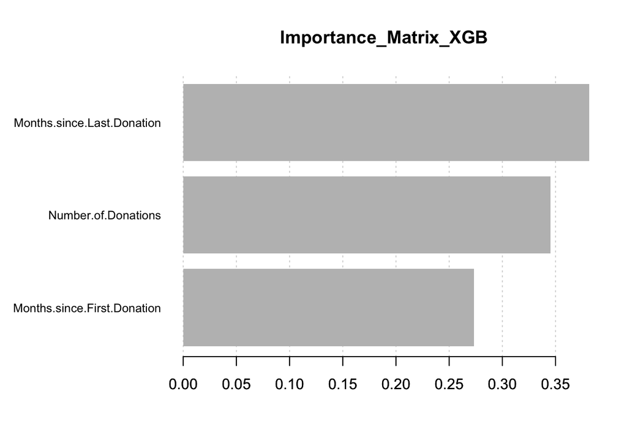

```r
xgb.plot.importance(importance_matrix=importance_matrix,cex=0.8,main="Importance_Matrix_XGB")
```

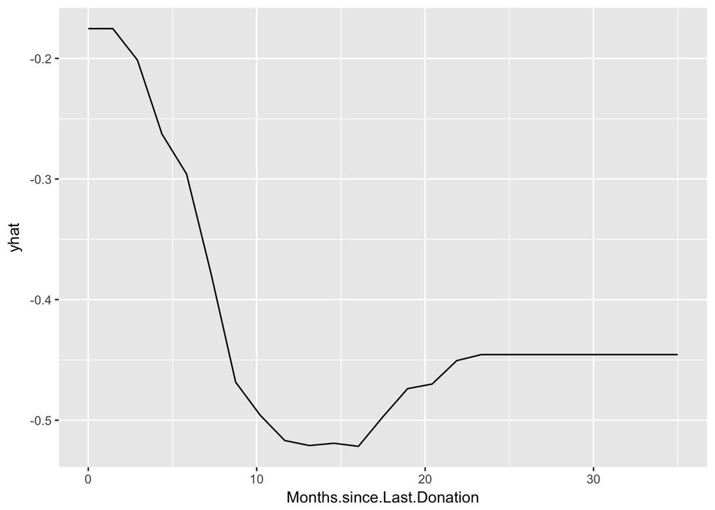

```r
### Partial Dependence by pdp
library("pdp")
pd1 <- partial(xgbmod, train=xtrain, pred.var = "Months.since.Last.Donation", chull = TRUE)
autoplot(pd1)
```

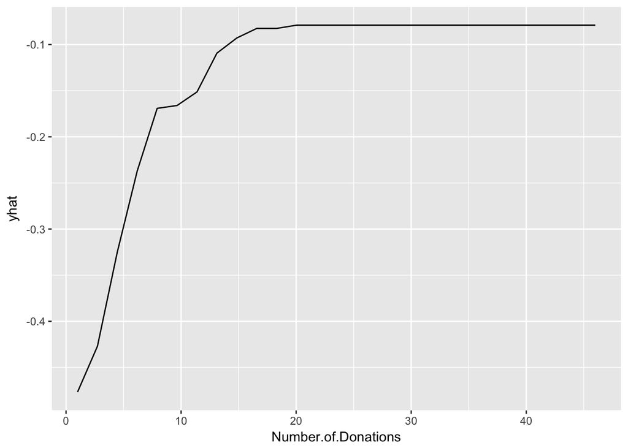

```r
pd2 <- partial(xgbmod, train=xtrain, pred.var = "Number.of.Donations", chull = TRUE)
autoplot(pd2)
```

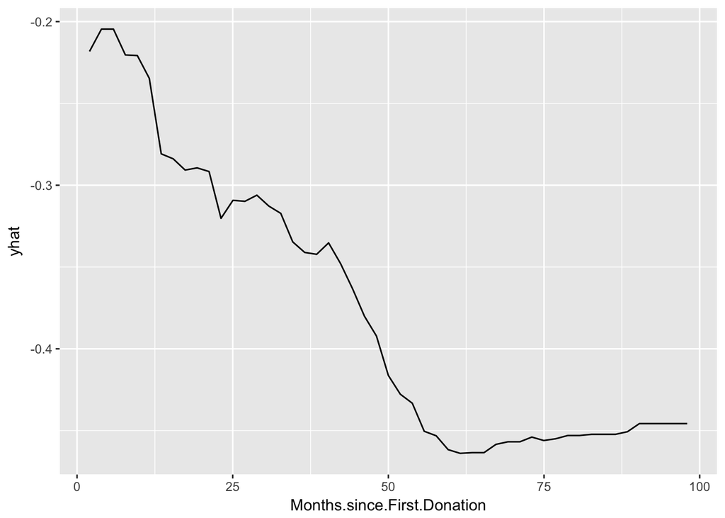

```r
pd3 <- partial(xgbmod, train=xtrain, pred.var = "Months.since.First.Donation", chull = TRUE)
autoplot(pd3)
```

```r
## categorical prediction (use fixed cutoff = 0.5)
xgb.prob <- predict(xgbmod, xvalid,type="prob")
xgb.pred <-ifelse(xgb.prob > 0.5,"P1","P0")

# confusion matrix
confusion.mat <- table(xgb.pred, datavalid$Made.Donation.in.March.2007)
confusion.mat
```

```
##
## xgb.pred   0   1
##       P0 125  27
##       P1   7  14
```

```r
misclassfication_rate_xgb <- 1 - (confusion.mat[2, 2] + confusion.mat[1, 1]) / nrow(datavalid)
misclassfication_rate_xgb
```

```
## [1] 0.1965318
```

### 2h) Prediction with validation datasets

```r
##Predict with valid data
predglm2a=predict(glm.best, newdata=datavalid,type="response")
predrid2b=predict(ridgecv, s=ridgelam, newx=xvalid,exact=TRUE,type="response")
predlas2c=predict(lassocv, s=lassolam, newx=xvalid,exact=TRUE,type="response")
predels2d=predict(elscv,s=elslam,newx=xvalid,type="response",exact=TRUE)
predtre2e=predict(tree1.pruned,newdata=datavalid,type="vector")
predrft2f=predict(tree2,newdata=datavalid,type="prob")
predxgb2g=predict(xgbmod, xvalid,type="prob")

head(predglm2a)
```

```
##         1         6         8        14        16        17
## 0.9731783 0.3918863 0.5465121 0.4307493 0.5428881 0.4407540
```

```r
head(predrid2b)
```

```
##            1
## 1  0.8475865
## 6  0.3284442
## 8  0.4355242
## 14 0.3591066
## 16 0.4362157
## 17 0.3661011
```

```r
head(predlas2c)
```

```
##            1
## 1  0.8883695
## 6  0.3345384
## 8  0.4663244
## 14 0.3738403
## 16 0.4683895
## 17 0.3825220
```

```r
head(predels2d)
```

```
##            1
## 1  0.8774286
## 6  0.3371313
## 8  0.4522496
## 14 0.3697293
## 16 0.4522985
## 17 0.3771949
```

```r
head(predtre2e)
```

```
##            0         1
## 1  0.3636364 0.6363636
## 6  0.4337349 0.5662651
## 8  0.4337349 0.5662651
## 14 0.4337349 0.5662651
## 16 0.4337349 0.5662651
## 17 0.4337349 0.5662651
```

```r
head(predrft2f)
```

```
##            0         1
## 1  0.5054945 0.4945055
## 6  0.3816184 0.6183816
## 8  0.3586414 0.6413586
## 14 0.4105894 0.5894106
## 16 0.1448551 0.8551449
## 17 0.1878122 0.8121878
```

```r
head(predxgb2g)
```

```
## [1] 0.4654776 0.4743907 0.5998777 0.5315300 0.5463400 0.5677235
```

### 2i) Ensemble model - Averaging

### There are many ways to ensemble the above models. Here we choose the simplest method which is simple averaging.

```r
predEnsemble_average = (predglm2a + predrid2b + predlas2c + predels2d + predtre2e[,2] + predrft2f[,2] + predxgb2g)/7
predEnsemble_average_yesno <- ifelse(predEnsemble_average > 0.5, 1, 0)
misclassification_rate_ensemble_average <- sum(predEnsemble_average_yesno != datavalid$Made.Donation.in.March.2007)/nrow(datavalid)
```

### 2i) Ensemble model - Majority

```r
predglm2a_yesno <- ifelse(predglm2a > 0.5, 1, 0)
predrid2b_yesno <- ifelse(predrid2b > 0.5, 1, 0)
predlas2c_yesno <- ifelse(predlas2c > 0.5, 1, 0)
predels2d_yesno <- ifelse(predels2d > 0.5, 1, 0)
predtre2e_yesno <- ifelse(predtre2e[,2] > 0.5, 1, 0)
predrft2f_yesno <- ifelse(predrft2f[,2] > 0.5, 1, 0)
predxgb2g_yesno <- ifelse(predxgb2g > 0.5, 1, 0)
pred.ensemble.2 <- data.frame(predglm2a_yesno , predrid2b_yesno,predlas2c_yesno,predels2d_yesno,predtre2e_yesno,predrft2f_yesno, predxgb2g_yesno)
require(functional)
finalPred <- apply(pred.ensemble.2, 1, Compose(table,
                                         function(i) i==max(i),
                                         which,
                                         names,
                                         function(i) paste0(i, collapse='/')
)
)
misclassification_rate_ensemble_majority <- sum(finalPred != datavalid$Made.Donation.in.March.2007)/nrow(datavalid)
misclassification_rate_ensemble_majority
```

```
## [1] 0.2312139
```

## 3) Model Comparison - XGBoosting is the best model - lowest misclassification rate

```r
# Define some palettes
palette_1_colors <- c("#0DA3A0")

misclassfication_rate_glm
```

```
## [1] 0.2254335
```

```r
misclassfication_rate_ridge
```

```
## [1] 0.2254335
```

```r
misclassfication_rate_lasso
```

```
## [1] 0.2254335
```

```r
misclassfication_rate_en
```

```
## [1] 0.2254335
```

```r
misclassfication_rate_tree
```

```
## [1] 0.2369942
```

```r
misclassfication_rate_rf
```

```
## [1] 0.2196532
```

```r
misclassfication_rate_xgb
```

```
## [1] 0.1965318
```

```r
misclassification_rate_ensemble_majority
```

```
## [1] 0.2312139
```

```r
misclassification_rate_ensemble_average
```

```
## [1] 0.2196532
```

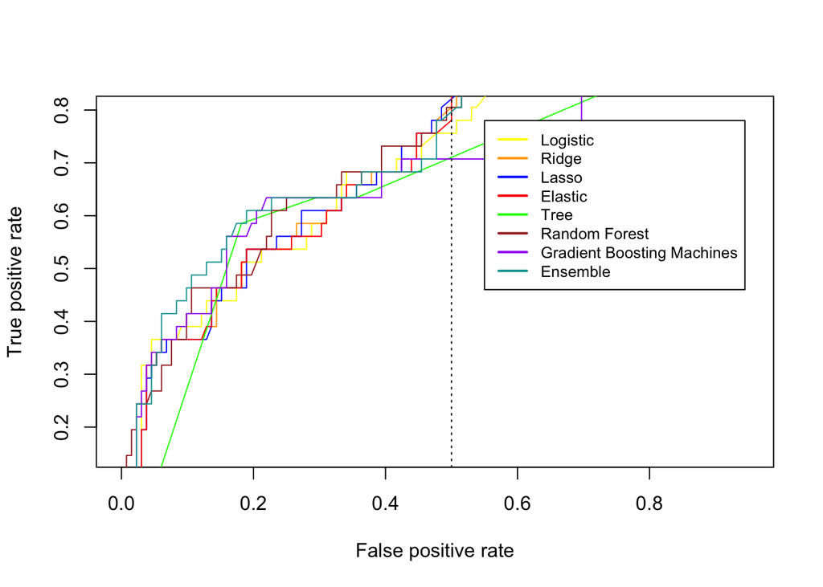

```r
library("ROCR")
modapred=prediction(predglm2a, yvalid)
modbpred=prediction(predrid2b, yvalid)
modcpred=prediction(predlas2c, yvalid)
moddpred=prediction(predels2d, yvalid)
modepred=prediction(predtre2e[,2], yvalid)
modfpred=prediction(predrft2f[,2], yvalid)
modgpred=prediction(predxgb2g, yvalid)
modEnsemblePred_avg=prediction(predEnsemble_average, yvalid)

# ROC Curve

ma.ROC <- performance(modapred, measure="tpr", x.measure="fpr")
mb.ROC <- performance(modbpred, measure="tpr", x.measure="fpr")
mc.ROC <- performance(modcpred, measure="tpr", x.measure="fpr")
md.ROC <- performance(moddpred, measure="tpr", x.measure="fpr")
me.ROC <- performance(modepred, measure="tpr", x.measure="fpr")
mf.ROC <- performance(modfpred, measure="tpr", x.measure="fpr")
mg.ROC <- performance(modgpred, measure="tpr", x.measure="fpr")
mh.ROC <- performance(modEnsemblePred_avg, measure="tpr", x.measure="fpr")

plot(ma.ROC, col="yellow",ylim=c(0.15,0.8),xlim=c(-0.0,0.95))
plot(mb.ROC, col="orange",ylim=c(0.15,0.8),xlim=c(-0.0,0.95),add=TRUE)
plot(mc.ROC, col="blue",add=TRUE)
plot(md.ROC, col="red",add=TRUE)
plot(me.ROC, col="green",add=TRUE)
plot(mf.ROC, col="brown",add=TRUE)
plot(mg.ROC, col="purple",add=TRUE)
plot(mh.ROC, col=palette_1_colors,add=TRUE)
abline(v=0.5,col="black",lty=3)

legend(x=0.55, y=0.78, legend=c("Logistic","Ridge","Lasso","Elastic","Tree", "Random Forest", "Gradient Boosting Machines","Ensemble"), lty=c(1, 1, 1), lwd=c(2, 2, 2), col=c("yellow","orange", "blue", "red","green","brown","purple",palette_1_colors),cex=0.8)
```

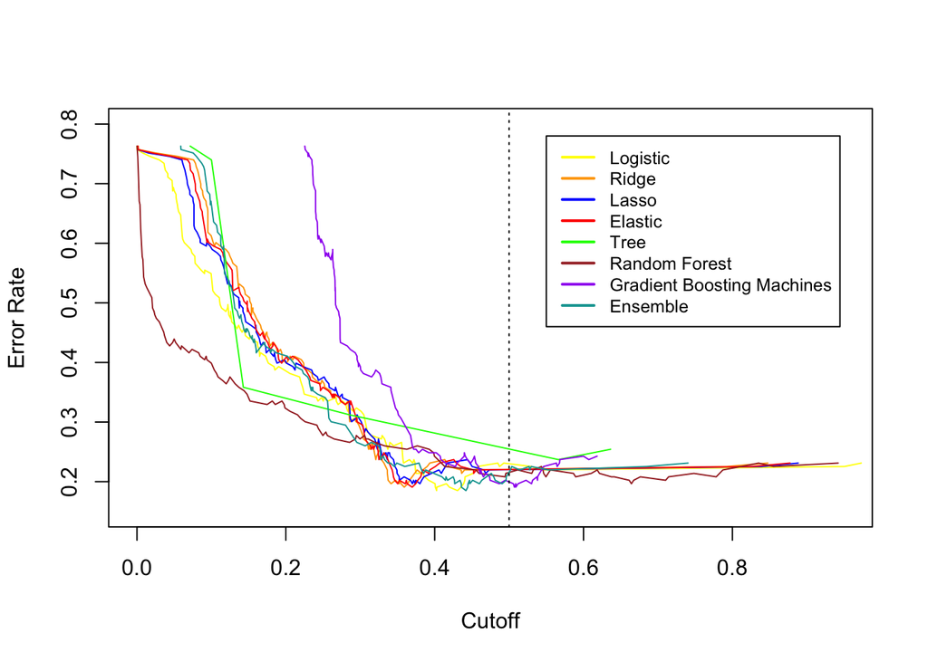

```r
# Plot of Misclassification rate against cutoff
ma.err=performance(modapred, measure="err")
mb.err=performance(modbpred, measure="err")
mc.err=performance(modcpred, measure="err")
md.err=performance(moddpred, measure="err")
me.err=performance(modepred, measure="err")
mf.err=performance(modfpred, measure="err")
mg.err=performance(modgpred, measure="err")
mEnsemble.avg.err=performance(modEnsemblePred_avg, measure="err")

plot(ma.err, col="yellow",ylim=c(0.15,0.8),xlim=c(-0.0,0.95))
plot(mb.err, col="orange",ylim=c(0.15,0.8),xlim=c(-0.0,0.95),add=TRUE)
plot(mc.err, col="blue",add=TRUE)
plot(md.err, col="red",add=TRUE)
plot(me.err, col="green",add=TRUE)
plot(mf.err, col="brown",add=TRUE)
plot(mg.err, col="purple",add=TRUE)
plot(mEnsemble.avg.err, col=palette_1_colors,add=TRUE)
abline(v=0.5,col="black",lty=3)

legend(x=0.55, y=0.78, legend=c("Logistic","Ridge","Lasso","Elastic","Tree", "Random Forest", "Gradient Boosting Machines","Ensemble"), lty=c(1, 1, 1), lwd=c(2, 2, 2), col=c("yellow","orange", "blue", "red","green","brown","purple",palette_1_colors),cex=0.8)
```

```r
# AUC values
ma.auc <- performance(modapred, "auc")
mb.auc <- performance(modbpred, "auc")
mc.auc <- performance(modcpred, "auc")
md.auc <- performance(moddpred, "auc")
me.auc <- performance(modepred, "auc")
mf.auc <- performance(modfpred, "auc")
mg.auc <- performance(modgpred, "auc")
mEnsemble.auc <- performance(modEnsemblePred_avg, "auc")

ma.auc@y.values[[1]]
```

```
## [1] 0.7355876
```

```r
mb.auc@y.values[[1]]
```

```
## [1] 0.742609
```

```r
mc.auc@y.values[[1]]
```

```
## [1] 0.7427938
```

```r
md.auc@y.values[[1]]
```

```
## [1] 0.7411308
```

```r
me.auc@y.values[[1]]
```

```
## [1] 0.6730414
```

```r
mf.auc@y.values[[1]]
```

```
## [1] 0.7389135
```

```r
mg.auc@y.values[[1]]
```

```
## [1] 0.7038987
```

```r
mEnsemble.auc@y.values[[1]]
```

```
## [1] 0.7577605
```

#### Best Model : We find best cutoff based on cost. False negative has lower cost than False positive

#### Reason is because we want to make sure that people are who are predicted to be return donors actually come

#### If we get flase negative, it means people who are not predicted to come actually come - which is not such a bad thing :)

#### We set the cutoff at the best cutoff above.

#### In terms of misclassification rate, the xgboost models performs best among all the models(lowest misclass rate)

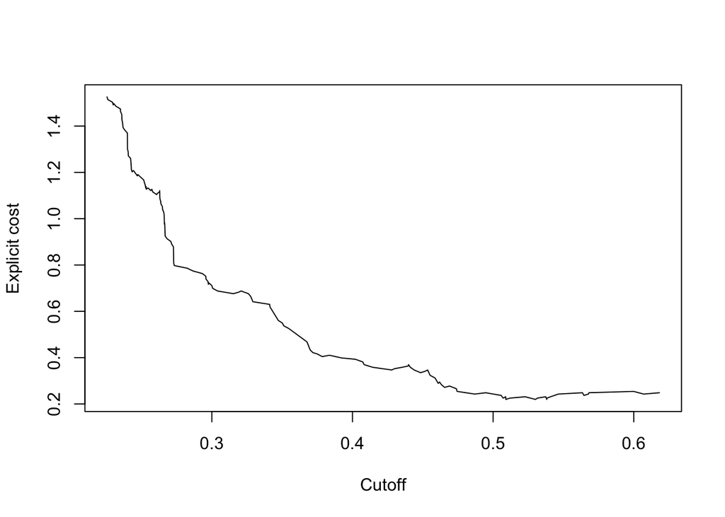

```r
cost.gbm <- performance(modgpred, measure = "cost", cost.fn = 1, cost.fp = 2)
plot(cost.gbm)
```

```r
minimum_cost <- which.min(cost.gbm@y.values[[1]])
minimum_cost
```

```
## [1] 12
```

```r
# Best cutoff that gives the minimum cost
best_cutoff <- cost.gbm@x.values[[1]][minimum_cost]
best_cutoff
```

```
## [1] 0.5381426
```

```r
xgb.prob <- predict(xgbmod, xvalid,type="prob")
xgb.pred <-ifelse(xgb.prob > best_cutoff,1,0)

# confusion matrix based on the optimal cutoff
confusion.mat <- table(xgb.pred, datavalid$Made.Donation.in.March.2007)
confusion.mat
```

```
##
## xgb.pred   0   1
##        0 129  33
##        1   3   8
```

```r
TP <- confusion.mat[2, 2]
TP
```

```
## [1] 8
```

```r
TN <- confusion.mat[1, 1]
TN
```

```
## [1] 129
```

```r
FP <- confusion.mat[2, 1]
FP
```

```
## [1] 3
```

```r
FN <- confusion.mat[1, 2]
FN
```

```
## [1] 33
```

```r
sensitivity <- TP / (TP + FN)
sensitivity
```

```
## [1] 0.195122
```

```r
fallout <- FP/ (FP + TN)
fallout
```

```
## [1] 0.02272727
```

```r
specificity <- TN / (FP + TN)
specificity
```

```
## [1] 0.9772727
```

```r
precision <- TP / (TP + FP)
precision
```

```
## [1] 0.7272727
```

```r
missout <- FN/ (TP + FN)
missout
```

```
## [1] 0.804878
```

```r
accuracy <- (TP + TN) / nrow(datavalid)
accuracy
```

```
## [1] 0.7919075
```